# Paralel Formalar Etibarlılığı

Ekvivalent Formalar Metodunun Tətbiqi və Analizi

Klassik Test Nəzəriyyəsi Kursu

2025-07-17

## 0.1 Dərsin Məqsədləri

✓ Paralel formalar etibarlılığının anlayışını və prinsiplərini öyrənmək  
✓ Ekvivalent formalar metodunun tətbiqi və xüsusiyyətlərini anlamaq  
✓ Alternativ formalar yaradılması və qiymətləndirilməsi bacarıqları qazanmaq  
✓ R-da paralel formalar analizləri aparma metodlarını mənimsəmək

## 0.2 Əvvəlki Dərslərə Baxış

**Dərs 1-5-də öyrəndiklərimiz:** - **X = T + E** modelinin əsasları və CTT fərziyyələri - **Etibarlılıq növləri** və onların xüsusiyyətləri - **Test-retest metodunun** güçlü və zəif tərəfləri - **Zaman intervalının** etibarlılığa təsiri

**İndi fokus:** Təcrübə və yaddaş effektlərindən qaçınmaq üçün **Paralel Formalar Etibarlılığı**

# 1 **Paralel Formalar Etibarlılığının Anlayışı**

## 1.1 **Paralel Testlərin Tərifi**

**Allen və Yen (2002, səh. 95-98)** kitabında paralel testlər belə təyin edilir:

> **Paralel testlər** - eyni konstruktu ölçən, statistik xüsusiyyətləri bərabər olan, lakin fərqli məzmunlu testlərdir.

### 1.1.1 **Paralel Testlərin Xüsusiyyətləri**

```r
# Paralel testlərin xarakteristikaları

parallel_characteristics <- data.frame(
  Xususiyyet = c("Eyni konstrukt", "Eyni çətinlik", "Eyni varyans",
                 "Eyni etibarlılıq", "Fərqli məzmun", "Eyni format"),

  Izah = c("Eyni qabiliyyəti ölçür", "Orta çətinlik eyni", "Bal səpələnməsi eyni",
           "Etibarlılıq əmsalı eyni", "Fərqli maddələr", "Eyni sual tipləri"),

  Riyazi_Ifade = c("Cor(X,Y) = Cor(X,T)", "μ_X = μ_Y", "σ²_X = σ²_Y",
                   "r_XX = r_YY", "X_i ≠ Y_i", "Format_X = Format_Y"),

  Yoxlama_Metodu = c("Korrelyasiya analizi", "t-test", "Levene testi",
                     "Cronbach α", "Məzmun ekspertizası", "Dizayn nəzarəti"),

  Kritik_Dərəcə = c(10, 9, 8, 9, 7, 6)
)

kable(parallel_characteristics[,-5], caption = "Paralel Testlərin Xüsusiyyətləri")
```

Paralel Testlərin Xüsusiyyətləri

| Xususiyyet | Izah | Riyazi_Ifade | Yoxlama_Metodu |
| --- | --- | --- | --- |
| Eyni konstrukt | Eyni qabiliyyəti ölçür | Cor(X,Y) = Cor(X,T) | Korrelyasiya analizi |
| Eyni çətinlik | Orta çətinlik eyni | μ_X = μ_Y | t-test |
| Eyni varyans | Bal səpələnməsi eyni | σ²_X = σ²_Y | Levene testi |
| Eyni etibarlılıq | Etibarlılıq əmsalı eyni | r_XX = r_YY | Cronbach α |
| Fərqli məzmun | Fərqli maddələr | X_i ≠ Y_i | Məzmun ekspertizası |
| Eyni format | Eyni sual tipləri | Format_X = Format_Y | Dizayn nəzarəti |

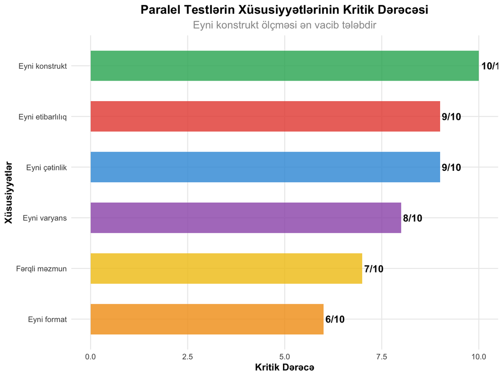

```r
# Xüsusiyyətlərin kritik dərəcəsi
ggplot(parallel_characteristics, aes(x = reorder(Xususiyyet, Kritik_Dərəcə),
                                    y = Kritik_Dərəcə, fill = Xususiyyet)) +
  geom_col(alpha = 0.8, width = 0.6) +
  geom_text(aes(label = paste0(Kritik_Dərəcə, "/10")),
            hjust = -0.1, fontface = "bold", size = 4) +
  coord_flip() +
  scale_fill_manual(values = colors_basic[1:nrow(parallel_characteristics)]) +
  labs(title = "Paralel Testlərin Xüsusiyyətlərinin Kritik Dərəcəsi",
       subtitle = "Eyni konstrukt ölçməsi ən vacib tələbdir",
       x = "Xüsusiyyətlər", y = "Kritik Dərəcə") +
  theme_clean() +
  theme(legend.position = "none") +
  ylim(0, 10)
```

## 1.2 **Ekvivalent Formalar**

**Ekvivalent formalar** paralel testlərin bir növüdür və aşağıdakı xüsusiyyətlərə malikdir:

### 1.2.1 **Ekvivalentlik Meyarları**

```r
# Ekvivalent formalar üçün meyarlar

equivalence_criteria <- data.frame(
  Meyar = c("Statistik Ekvivalentlik", "Məzmun Ekvivalentliyi", "Konstrukt Ekvivalentliyi",
            "Ədalətlik", "Praktik Ekvivalentlik", "Psixometrik Ekvivalentlik"),

  Tələb = c("Eyni orta və varyans", "Eyni mövzu sahəsi", "Eyni faktorial struktur",
            "Qrup fərqləri yox", "Eyni vaxt və format", "Eyni item statistikaları"),

  Test_Metodu = c("t-test, F-test", "Ekspert qiymətləndirməsi", "Faktor analizi",
                  "DIF analizi", "Pilot test", "IRT analizi"),

  Qebul_Kriteriya = c("p > 0.05", "90%+ razılıq", "CFI > 0.95", "DIF < 0.05",
                      "Vaxt fərqi < 10%", "Parametrlər eyni"),

  Çətinlik_Səviyyəsi = c("Orta", "Yüksək", "Yüksək", "Çox yüksək", "Aşağı", "Çox yüksək")
)

kable(equivalence_criteria, caption = "Ekvivalent Formalar üçün Meyarlar")
```

Ekvivalent Formalar üçün Meyarlar

| Meyar | Tələb | Test_Metodu | Qebul_Kriteriya | Çətinlik_Səviyyəsi |
| --- | --- | --- | --- | --- |
| Statistik Ekvivalentlik | Eyni orta və varyans | t-test, F-test | p > 0.05 | Orta |
| Məzmun Ekvivalentliyi | Eyni mövzu sahəsi | Ekspert qiymətləndirməsi | 90%+ razılıq | Yüksək |
| Konstrukt Ekvivalentliyi | Eyni faktorial struktur | Faktor analizi | CFI > 0.95 | Yüksək |
| Ədalətlik | Qrup fərqləri yox | DIF analizi | DIF < 0.05 | Çox yüksək |
| Praktik Ekvivalentlik | Eyni vaxt və format | Pilot test | Vaxt fərqi < 10% | Aşağı |
| Psixometrik Ekvivalentlik | Eyni item statistikaları | IRT analizi | Parametrlər eyni | Çox yüksək |

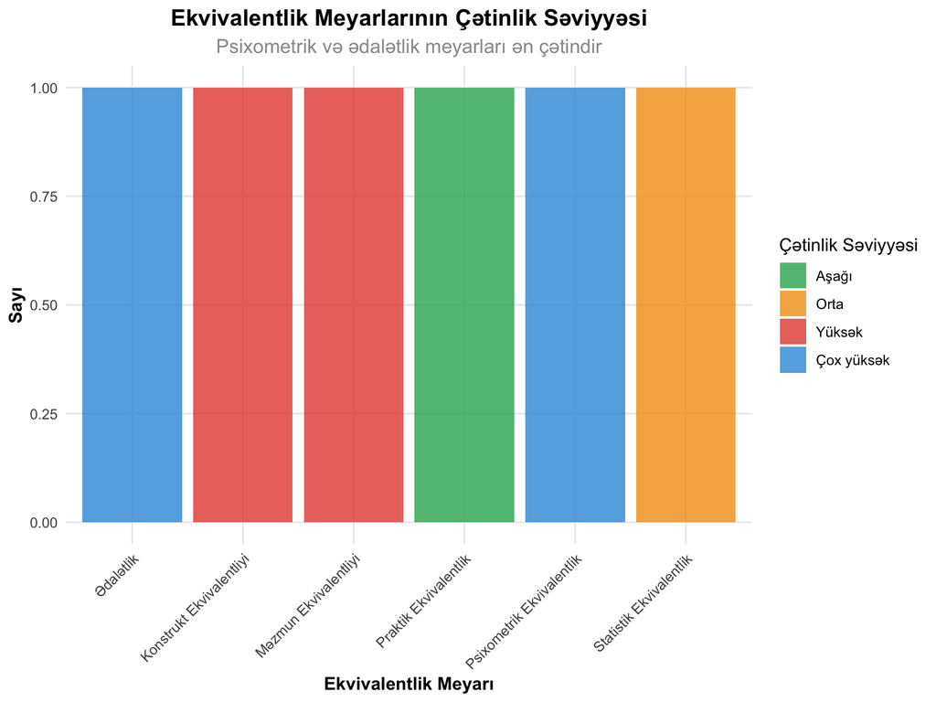

```r
# Meyarların çətinlik səviyyəsi
difficulty_levels <- factor(equivalence_criteria$Çətinlik_Səviyyəsi,
                           levels = c("Aşağı", "Orta", "Yüksək", "Çox yüksək"))

ggplot(equivalence_criteria, aes(x = Meyar, fill = difficulty_levels)) +
  geom_bar(alpha = 0.8) +
  scale_fill_manual(values = c("Aşağı" = colors_basic[4], "Orta" = colors_basic[3],
                              "Yüksək" = colors_basic[2], "Çox yüksək" = colors_basic[1]),
                    name = "Çətinlik Səviyyəsi") +
  labs(title = "Ekvivalentlik Meyarlarının Çətinlik Səviyyəsi",
       subtitle = "Psixometrik və ədalətlik meyarları ən çətindir",
       x = "Ekvivalentlik Meyarı", y = "Sayı") +
  theme_clean() +
  theme(axis.text.x = element_text(angle = 45, hjust = 1))
```

## 1.3 **Alternativ Formalar**

**Alternativ formalar** daha çevik bir yanaşmadır:

- **Eyni konstruktu ölçür** amma tam statistik ekvivalentlik tələb etmir
- **Fərqli çətinlik səviyyəsi** ola bilər
- **Müxtəlif məzmun** və format istifadə edə bilər
- **Praktik tətbiqlər** üçün daha uyğundur

```r
# Paralel, ekvivalent və alternativ formalar müqayisəsi

forms_comparison <- data.frame(
  Xususiyyet = c("Statistik ekvivalentlik", "Məzmun ekvivalentliyi", "Format ekvivalentliyi",
                 "Çətinlik səviyyəsi", "Vaxt tələbi", "Hazırlama çətinliyi",
                 "Praktik istifadə", "Etibarlılıq dəqiqliyi"),

  Paralel_Formalar = c("Tam", "Tam", "Tam", "Tam eyni", "Eyni", "Çox yüksək",
                       "Məhdud", "Ən yüksək"),

  Ekvivalent_Formalar = c("Çox yüksək", "Yüksək", "Yüksək", "Çox oxşar", "Çox oxşar", "Yüksək",
                          "Yaxşı", "Yüksək"),

  Alternativ_Formalar = c("Orta", "Orta", "Çevik", "Fərqli ola bilər", "Çevik", "Orta",
                          "Çox yaxşı", "Orta")
)

kable(forms_comparison, caption = "Form Növlərinin Müqayisəsi")
```

Form Növlərinin Müqayisəsi

| Xususiyyet | Paralel_Formalar | Ekvivalent_Formalar | Alternativ_Formalar |
| --- | --- | --- | --- |
| Statistik ekvivalentlik | Tam | Çox yüksək | Orta |
| Məzmun ekvivalentliyi | Tam | Yüksək | Orta |
| Format ekvivalentliyi | Tam | Yüksək | Çevik |
| Çətinlik səviyyəsi | Tam eyni | Çox oxşar | Fərqli ola bilər |
| Vaxt tələbi | Eyni | Çox oxşar | Çevik |
| Hazırlama çətinliyi | Çox yüksək | Yüksək | Orta |
| Praktik istifadə | Məhdud | Yaxşı | Çox yaxşı |
| Etibarlılıq dəqiqliyi | Ən yüksək | Yüksək | Orta |

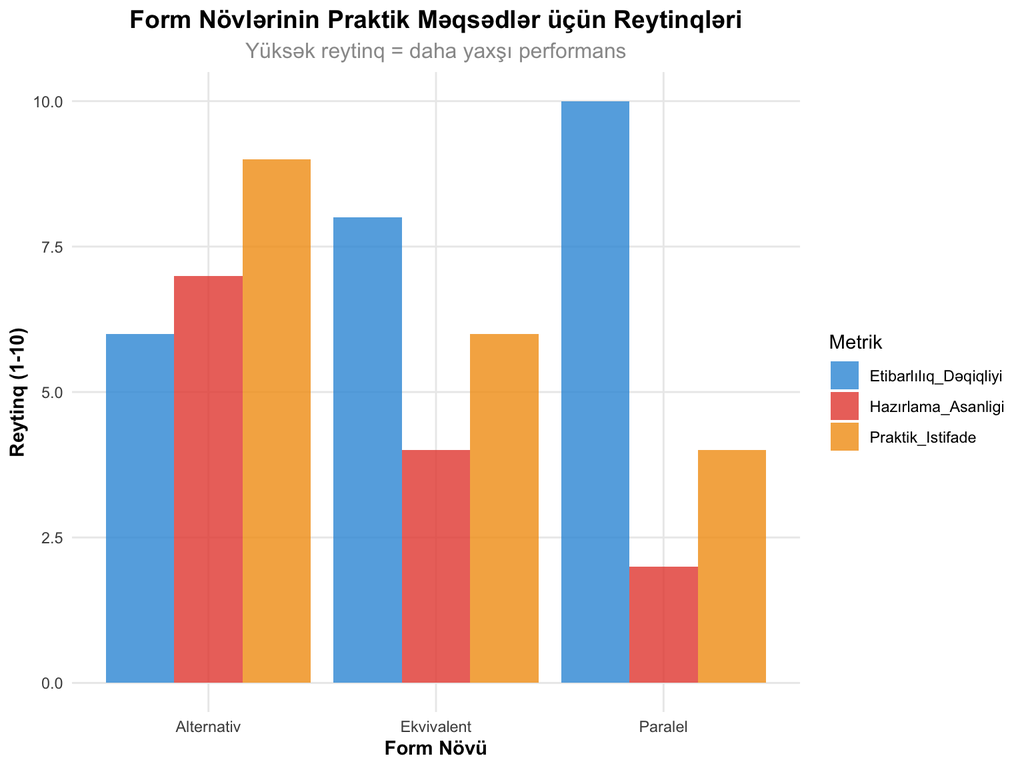

```r
# Praktik istifadə reytinqləri
practical_ratings <- data.frame(
  Form_Novu = c("Paralel", "Ekvivalent", "Alternativ"),
  Hazırlama_Asanligi = c(2, 4, 7),
  Praktik_Istifade = c(4, 6, 9),
  Etibarlılıq_Dəqiqliyi = c(10, 8, 6)
)

practical_long <- tidyr::pivot_longer(practical_ratings, cols = -Form_Novu,
                                     names_to = "Metrik", values_to = "Reytinq")

ggplot(practical_long, aes(x = Form_Novu, y = Reytinq, fill = Metrik)) +
  geom_col(position = "dodge", alpha = 0.8) +
  scale_fill_manual(values = colors_basic[1:3]) +
  labs(title = "Form Növlərinin Praktik Məqsədlər üçün Reytinqləri",
       subtitle = "Yüksək reytinq = daha yaxşı performans",
       x = "Form Növü", y = "Reytinq (1-10)") +
  theme_clean()
```